# Social factors in access to food and policy recommendation

Caleb Sigmon

2024-04-03

## Precondition

### Learning

The US Department of Agriculture data from 2021 records number of people by county and breaks them into their counts for different categories of distance from a supermarket. This includes additional dividing categories like the number of people by distance that are low income, that don’t have car access, that have children, and that are senior citizens. Race is not included.

Findings from Feed America https://www.feedingamerica.org/sites/default/files/2021-03/National%20Projections%20Brief_3.9.2021_0.pdf show that there are some alarming—though not entirely unexpected—trends between races. One in 12 white non-hispanic people in the data lived in a food-insecure household. For Latino people the number is one in six, for Black people it’s one in five, and most drastically of all, for Native American people the number is one in four.

One explanation is the poverty rates among Native American peoples. The most recent report on poverty by the US Administration for Native Americans is from 2012 and states “The poverty rate for American Indians living on reservations is 29.4 percent compared with the U.S. national average of 15.3 percent. The reservation poverty rate for Indian families is 36 percent, compared to the national family poverty rate of 9.2 percent.” So Native Americans’ economic status is not favorable, especially when grouped by families.

Move for Hunger additonally states “There are a total of 28 counties in America that are majority Native American, and 18 of those counties are considered high food insecurity counties.”

## Core

### Discover

In line with the precondition, two tasks that the study wants to enable on the data is being able to compare the counts of a county statistic as compared to the other counties in the state and across the country.

- The task of comparing statistics for the counties across a state is to give accurate context since not all states have a county with a majority Native American population; in fact most don’t. The task will be conducted by selecting for different attributes to compare, amongst low income, no car access, and total population that are beyond 20 miles away from a supermarket. This task should be able to show if the counties with majority Native American populations have any trends or extreme values. This could be used to provide lawmakers, lobbyists and concerned citizens with an increased awareness of help needed for native peoples. It may even show states or counties that are good examples of food accessibility.
- The task of comparing statistics for different counties across the country may show how the native american counties are very much on one end of the spectrum and examples of higher than average need.

### Design

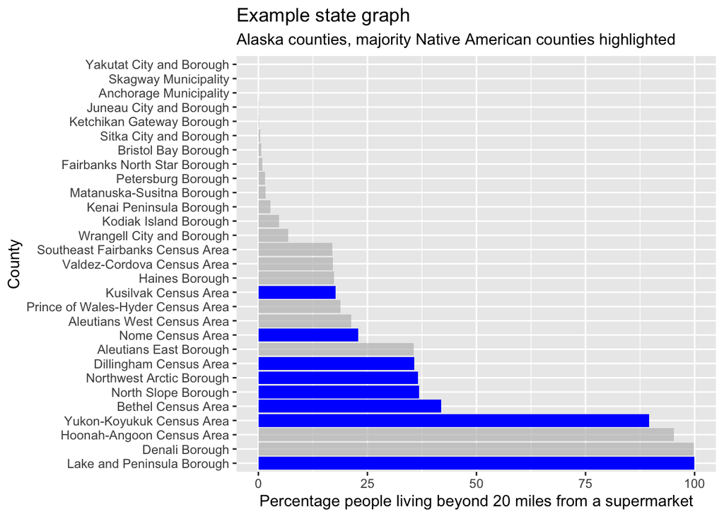

This is a prototype of one graph that could be generated by a user selecting attributes. Here for example, if the user had selected Alaska and the percentage of people living over 20 miles from a supermarket as the attribute, they could see a stark comparison of counties that are majority native occupying more spots in the higher percentages.

### Implement

Now for the full fledged interactive visualization, the data from the DOA is recreated as a JSON file and loaded into a chartJS chart whose parameters are adjusted by user selections from dropdowns.

Users can see the states that have counties that are majority Native American marked in blue. Users can click on the map to render data for that state, and click on it again to deselect and return to rendering data for the entire US. The dropdown described above has been provided to select different attributes to chart, along with a checkbox to exclude counties from the graph where the percentage of that selected attribute would be equal to zero. Finally, because the US has a very large number of counties, as do some states, a range slider is added to allow zooming in to the top selected percent of percentage values by county for that state or entire US.

[figure not shown]

State select: Entire US

Choose an attribute: Exclude percentages equal to 0:

[interactive chart not shown]

Top 0 percent | Counties

### Deploy

As expected, looking through different attributes by state and across the country does show that majority Native American counties tend to have greater percentages of their population living over 20 miles from a supermarket, and in a few categories they actually mark the extreme highest.

### Iterate

Looking at the data now that it’s charted, more detail on distance from a supermarket is something I would want to investigate, instead of putting things into just counts of over 20 miles away or not, putting counts into bins of less than 1/2 mile, over 1/2 mile, over 1 mile, over 10 miles and over 20 miles. To accommodate this task I would break each bar into segments representing those bins, with their color filling the bar in a representative percentage of that county’s population.